# Exploratory Data Analysis of P2P-Lending sites

Analyzing Loan Data From Prosper.com

Frederik Tischbein

November 3rd, 2018

## Introduction

Prosper is a peer-to-peer lending marketplace. Borrowers apply online for a fixed-rate, fixed-term loan between 2000 and $40,000. Individuals and institutions can invest in the loans and earn attractive returns. Prosper handles all loan servicing on behalf of the matched borrowers and investors.

In this analysis I will focus on the question of factors influencing the borrowing rate an individual recieves when applying for a loan on Prosper.com. My exploration and analysis of the different variables in the dataset and their relationship are the basis for a linear model, which I will introduce in the second part, which can predict the borrowing rate an indivudal will recieve.

## Structure of the dataset

```
## Observations: 113,937
## Variables: 81
## $ ListingKey                          <fct> 1021339766868145413AB3B, 1...
## $ ListingNumber                       <int> 193129, 1209647, 81716, 65...
## $ ListingCreationDate                 <fct> 2007-08-26 19:09:29.263000...
## $ CreditGrade                         <fct> C, , HR, , , , , , , , , C...
## $ Term                                <int> 36, 36, 36, 36, 36, 60, 36...
## $ LoanStatus                          <fct> Completed, Current, Comple...
## $ ClosedDate                          <fct> 2009-08-14 00:00:00, , 200...
## $ BorrowerAPR                         <dbl> 0.16516, 0.12016, 0.28269,...
## $ BorrowerRate                        <dbl> 0.1580, 0.0920, 0.2750, 0....
## $ LenderYield                         <dbl> 0.1380, 0.0820, 0.2400, 0....
## $ EstimatedEffectiveYield             <dbl> NA, 0.07960, NA, 0.08490, ...
## $ EstimatedLoss                       <dbl> NA, 0.0249, NA, 0.0249, 0....
## $ EstimatedReturn                     <dbl> NA, 0.05470, NA, 0.06000, ...
```

[output cut: 68 more lines]

The dataset set contains 113,937 observations with 81 variables, including the loan amount, borrower rate (or interest rate), current loan status, borrower income, borrower employment status, borrower credit history, and the latest payment information. A detailed description of all the variables in the dataset can be found [here](https://rstudio-pubs-static.s3.amazonaws.com/86324_ab1e2e2fa210452f80a1c6a1476d7a2a.html).

## Data Wrangling & Cleaning

Looking at the structure of the dataset, we can notice a couple of things we need to fix in order to analyze the data more easily:

- According to the Prosper API documentation, the `ListingCategory..numeric.` variable describes the Listing category the borrower selected when posting their listing. We want to replace the numeric value with the category belonging to this number.
- Secondly, we need to adjust the structure of the `LoanOriginationDate` and the `LoanOriginationQuarter` columns to be able to analyze the data over time. The `lubridate`, `dplyr` and `tidyr`packages come in handy here.
- And third, we combine two variables of creditworthyness, the `CreditGrade` (used for loans pre 2009) and the `ProsperRating(alpha)`(used for loans originated after July 2009) into one column called `CreditRating`.

```r
# Replacing the numeric listing category with the category defined by the API
code2category <- function(code) {
  categories = c("Not Available", "Debt Consolidation", "Home Improvement",
                 "Business", "Personal Loan", "Student Use", "Auto", "Other",
                 "Baby&Adoption", "Boat", "Cosmetic Procedure",
                 "Engagement Ring", "Green Loans", "Household Expenses",
                 "Large Purchases", "Medical/Dental", "Motorcycle", "RV",
                 "Taxes", "Vacation", "Wedding Loans")
  categories[2+1]
  return (categories[(code + 1)]) # in R Vector index starts at 1 not 0
}
prosper$ListingCategory <- sapply(prosper$ListingCategory, code2category)
```

```r
# Parsing the LoanOriginationDate column into the "date"-Format
prosper$LoanOriginationDate <- as_date(prosper$LoanOriginationDate)


# Transforming LoanOriginationQuarter from [Q# Year] to [Year Q#]
# This will make sorting and plotting much easier
prosper$LoanOriginationQuarter <- as.character(prosper$LoanOriginationQuarter)
prosper <- prosper %>%
            separate(col = LoanOriginationQuarter,
                      into = c("Quarter", "Year"), sep = " ") %>%
            unite(col = LoanOriginationQuarter, Year, Quarter, sep = " ")

# Making a LoanOriginationQuarterF column
prosper$LoanOriginationQuarterF <- factor(prosper$LoanOriginationQuarter)

# Due to the transformed LoanOriginationQuarter column the standard order is
# Q1 2006 Q2 2006 Q3 2006 Q4 2007 Q1 2007...
```

```r
# Joining the ProsperScore(alpha) and the CreditGrade into one column
prosper <- unite(prosper, col = "CreditRating",
                 c("CreditGrade", "ProsperRating..Alpha."), sep = "")
prosper$CreditRating <- as.character(prosper$CreditRating)

# Setting CreditRating with the values "" or NC to NA
prosper$CreditRating[prosper$CreditRating == ""] <- NA
prosper$CreditRating[prosper$CreditRating == "NC"] <- NA

# Turning the variable into an ordered factor
prosper$CreditRating <- ordered(prosper$CreditRating,
                              labels = c("AA","A","B","C","D", "E", "HR"))
```

## Univariate Plots

Great, let’s explore the dataset! First, let’s look at the size and status of loans issued on prosper.com:

Summary of Loan amounts:

```
##    Min. 1st Qu.  Median    Mean 3rd Qu.    Max.
##    1000    4000    6500    8337   12000   35000
```

Plots:

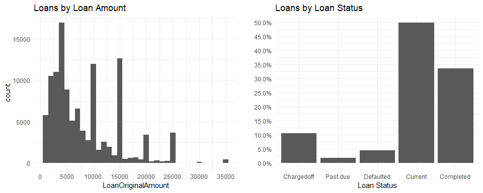

But for what kind of investements do people take a loan?

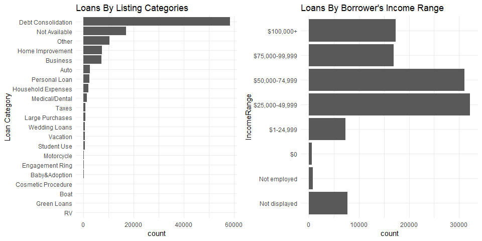

- Debt Consilidation (i.e. a form of debt refinancing that entails taking out one loan to pay off many others), is by far the most popular reason for people to take on a loan. In fact, as explained in [this](https://www.forbes.com/sites/andrewjosuweit/2017/09/09/how-to-use-a-peer-to-peer-loan-to-pay-off-high-interest-debt/#5c2459551f79) article it is an attractive option to pay-off high interest debt, such as credit cards.
- In the plot on the right, we can see that most of the borrowers on prosper have a lower-medium to medium income.
- Let’s have a closer look at the monthly income of users:

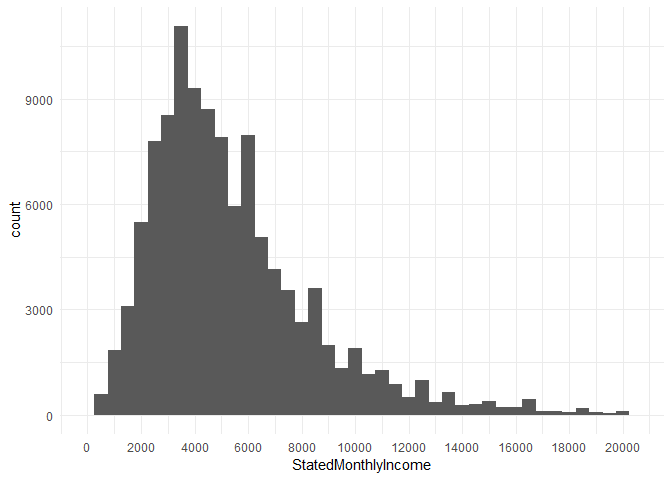

```
##    Min. 1st Qu.  Median    Mean 3rd Qu.    Max.
##       0    3200    4667    5608    6825 1750003
```

- The median income of borrower is 4667. The distribution is right-skewed with outliers earning over a million a month.
- Lets look at monthly Loan payments:

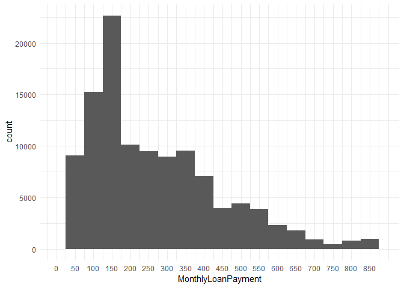

- Most common is a monthly loan payment of 100-150$. Let’s set the monthly payment into relation to the monthly income, i.e. the percentage of the monthly income payed for the loan:

```
##    Min. 1st Qu.  Median    Mean 3rd Qu.    Max.    NA's
## 0.00000 0.02859 0.04962     Inf 0.07865     Inf      15
```

## Plotting Time-Series

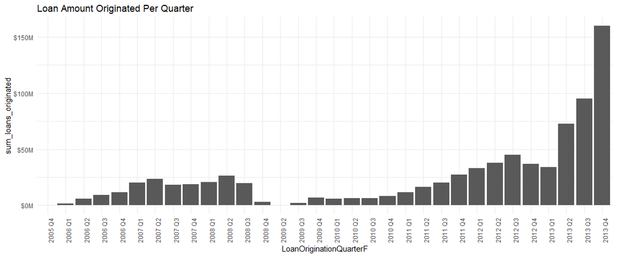

- Clearly, there is an upwards trend of loans beeing originated on prosper. In 2013, growth has been very especially fast.
- There is a lowpoint in Q2 2009. A possible explanation for this is that Prosper relaunched in July 2009, after having obtained SEC registration for its loans.

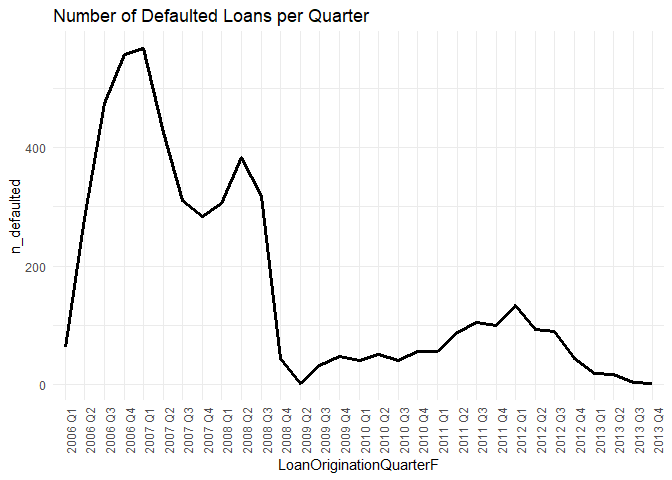

- In the early years of Prosper, the number of defaulted loans was higher.

## Bivariate Plots

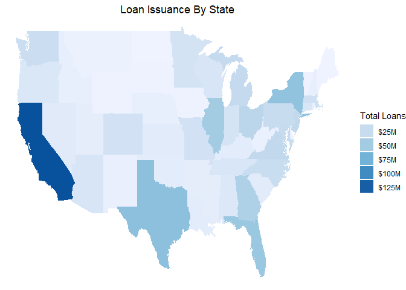

- As we can see, the state with the highest total of loans issued so far is California (> $125M).
- On second place there is Texas, New York and Florida which all have araound 55 -60M $ of total loans.

What type of rates are borrowers getting on prosper.com?

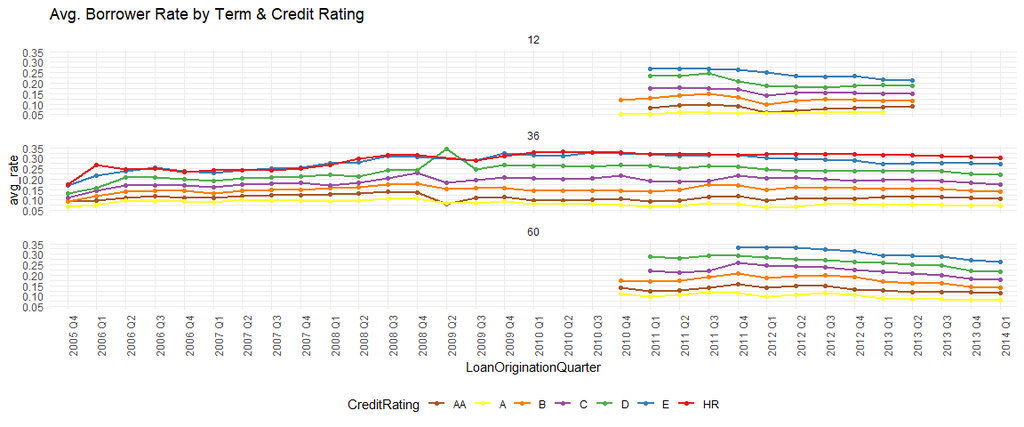

- Ok looks like, 12-month and 60-month loans have only been given out since Q4 2010 / Q1 2011. (Interestingly starting with borrowers with a good creddit rating, before they were accessible for borrowers of all credit classes).
- What is striking about the plot is the jump in Q2 2009 for the rate of borrowers with a D credit rating. The rates of all other credit classes slightly decrease in that quarter. A reason for this odd feature might be the change between the two types of credit scores which happened during that time and which we combined in our data.
- Lets focus in the next plot on the time from 2011 onwards, during which all 3 types of loans were offered.

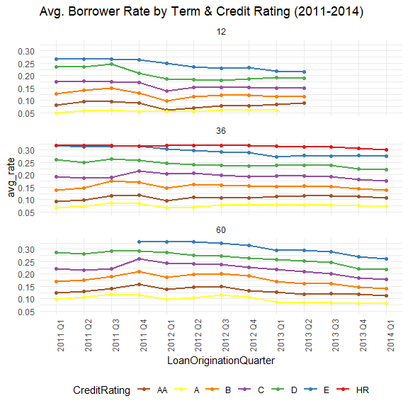

Adding a summary of the average rates per loan (data from 2011 onwards):

```
## # A tibble: 19 x 3
## # Groups:   Term [?]
##     Term CreditRating avg_rate
##    <int> <ord>           <dbl>
##  1    12 AA             0.0786
##  2    12 A              0.0566
##  3    12 B              0.120
##  4    12 C              0.153
##  5    12 D              0.208
##  6    12 E              0.247
##  7    36 AA             0.110
##  8    36 A              0.0750
##  9    36 B              0.150
## 10    36 C              0.189
## 11    36 D              0.243
## 12    36 E              0.292
## 13    36 HR             0.316
## 14    60 AA             0.127
## 15    60 A              0.0998
## 16    60 B              0.162
## 17    60 C              0.201
## 18    60 D              0.250
## 19    60 E              0.294
```

## What factors influence the borrower rate?

First, lets see how the employment status affects the borrower rate:

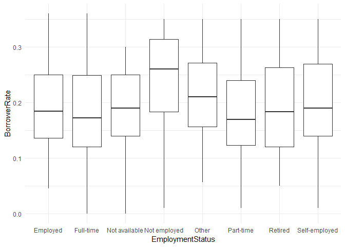

- Although there is some overlap in the different definitons of EmploymentStatus, it becomes clear that the median borrower rate for unemployed borrowers is higher.

Does it affect the BorrowerRate if the borrower owns a house?

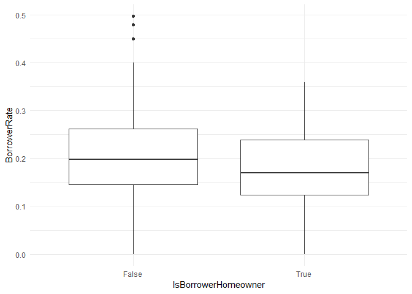

- HomeOwners get a lower rate then people not owning a house. This makes sense, because homeowners can always sell or put a mortage on their homes.

Next, let’s take the view of the lenders. What return can they excpect?

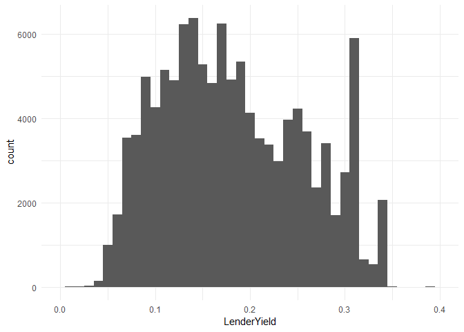

```
##    Min. 1st Qu.  Median    Mean 3rd Qu.    Max.
## -0.0100  0.1242  0.1730  0.1827  0.2400  0.4925
```

- The lender yield is the interest rate minus the expected fee payments.
- It is one of the most important metrics for lenders.
- As we can see, the median lender yield is ~17%. The distribution seems to be bimodal, peaking again at 31%. We will look further into this at a later point.

## Correlations between different features

Because, the dataset contains over 80 different variables, let’s first subset it to the ones most relevant to our investigation:

```r
prosper_sub <- prosper[c("BorrowerRate", "CreditRating","ProsperScore", "Term", "BorrowerAPR",
                         "DebtToIncomeRatio", "StatedMonthlyIncome", "AvailableBankcardCredit", "EmploymentStatus")]
```

Next, let’s use the `GGally` package to create a correlation matrix of these variables. This wil give us a good overview:

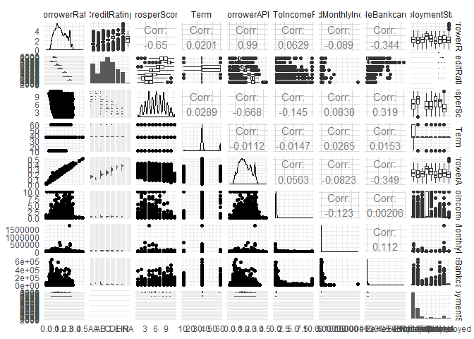

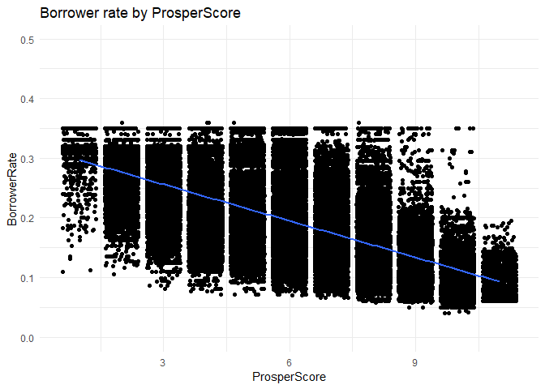

```r
cor(prosper$BorrowerRate, prosper$ProsperScore, use = "complete.obs")
```

```
## [1] -0.6497361
```

- As the plot and the calculation of the correlation coefficient show, the Prosper Score and the Borrower Rate are negatively correlated (-0.65). This makes sense, since the Prosper Score is baded on the Credit Rating of the individual. With a better (higher) score, the risk is lower and a better rate can be offered.

## Multivariate Plots

Let’s further investigate the relationship between a borrowers prosper score, credit rating and borrowing rate:

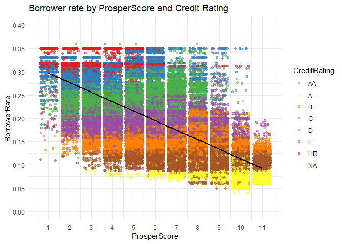

- Again, we can see that persons with an higher Prosper Score revieve the better borrowing rates.
- By adding a coloring by Credit Rating, we can see a clear differentiation in the borrowing rates of the different credit ratings.
- What is interesting is that prosper seems to set certain max. borrowing rates for the different credit classes. Therefore in the plot there is a clear cut at a borrowing rate 0f 36%. Only a view outliers have a borrowing rate above that level.

Next, let’s come back to Prospers overall performance over the years. We have seen before, that the total amount of loans originated has increased over the years. But what is even more relevant is the development of defaulted vs. currrent loans.

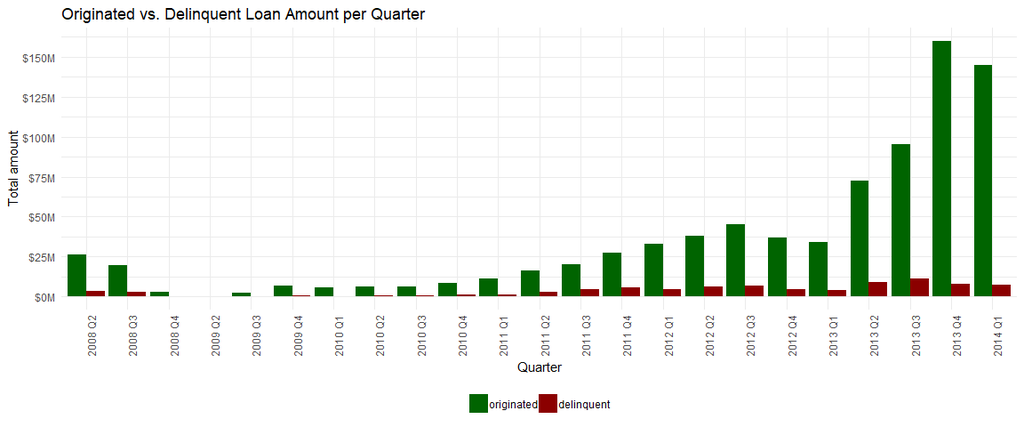

## Building a linear model to predict the Borrower Rate

```r
# Building the model, bottom up approach
m1 <- lm(BorrowerRate ~ CreditRating, data = prosper)
m2 <- update(m1, ~ . + StatedMonthlyIncome)
m3 <- update(m2, ~ . + IsBorrowerHomeowner)
m4 <- update(m3, ~ . + EmploymentStatus)
m5 <- update(m4, ~ . + AvailableBankcardCredit)
m6 <- update(m5, ~ . + DebtToIncomeRatio)

# Summary of the r-squared tests of the different models
mtable(m1,m2, m3, m4, m5, m6)
```

```
##
## Calls:
## m1: lm(formula = BorrowerRate ~ CreditRating, data = prosper)
## m2: lm(formula = BorrowerRate ~ CreditRating + StatedMonthlyIncome,
##     data = prosper)
## m3: lm(formula = BorrowerRate ~ CreditRating + StatedMonthlyIncome +
##     IsBorrowerHomeowner, data = prosper)
## m4: lm(formula = BorrowerRate ~ CreditRating + StatedMonthlyIncome +
##     IsBorrowerHomeowner + EmploymentStatus, data = prosper)
## m5: lm(formula = BorrowerRate ~ CreditRating + StatedMonthlyIncome +
##     IsBorrowerHomeowner + EmploymentStatus + AvailableBankcardCredit,
##     data = prosper)
## m6: lm(formula = BorrowerRate ~ CreditRating + StatedMonthlyIncome +
##     IsBorrowerHomeowner + EmploymentStatus + AvailableBankcardCredit +
##     DebtToIncomeRatio, data = prosper)
##
## ============================================================================================================================================
##                                                   m1              m2              m3              m4              m5              m6
## --------------------------------------------------------------------------------------------------------------------------------------------
##   (Intercept)                                     0.195***        0.195***        0.192***        0.197***        0.198***        0.196***
##                                                  (0.000)         (0.000)         (0.000)         (0.000)         (0.000)         (0.000)
##   CreditRating: .L                                0.193***        0.193***        0.195***        0.198***        0.201***        0.201***
##                                                  (0.000)         (0.000)         (0.000)         (0.000)         (0.000)         (0.000)
##   CreditRating: .Q                                0.013***        0.013***        0.013***        0.015***        0.017***        0.017***
##                                                  (0.000)         (0.000)         (0.000)         (0.000)         (0.000)         (0.000)
##   CreditRating: .C                               -0.040***       -0.040***       -0.041***       -0.040***       -0.039***       -0.039***
##                                                  (0.000)         (0.000)         (0.000)         (0.000)         (0.000)         (0.000)
##   CreditRating: ^4                                0.014***        0.014***        0.015***        0.014***        0.014***        0.014***
##                                                  (0.000)         (0.000)         (0.000)         (0.000)         (0.000)         (0.000)
##   CreditRating: ^5                               -0.021***       -0.021***       -0.021***       -0.020***       -0.021***       -0.021***
##                                                  (0.000)         (0.000)         (0.000)         (0.000)         (0.000)         (0.000)
##   CreditRating: ^6                                0.008***        0.008***        0.008***        0.008***        0.008***        0.008***
##                                                  (0.000)         (0.000)         (0.000)         (0.000)         (0.000)         (0.000)
##   StatedMonthlyIncome                                             0.000***        0.000*         -0.000          -0.000           0.000***
##                                                                  (0.000)         (0.000)         (0.000)         (0.000)         (0.000)
##   IsBorrowerHomeowner: True/False                                                 0.006***        0.005***        0.004***        0.005***
##                                                                                  (0.000)         (0.000)         (0.000)         (0.000)
##   EmploymentStatus: Full-time/Employed                                                           -0.006***       -0.007***       -0.007***
##                                                                                                  (0.000)         (0.000)         (0.000)
##   EmploymentStatus: Not available/Employed                                                       -0.035***       -0.029***       -0.029***
```

[output cut: 12 more lines]

```
##                                                                                                                  (0.000)         (0.000)
##   DebtToIncomeRatio                                                                                                               0.003***
##                                                                                                                                  (0.000)
## --------------------------------------------------------------------------------------------------------------------------------------------
##   R-squared                                       0.781           0.781           0.783           0.801           0.813           0.816
##   adj. R-squared                                  0.781           0.781           0.783           0.801           0.813           0.816
##   sigma                                           0.035           0.035           0.035           0.033           0.032           0.032
##   F                                           67597.375       57958.701       51149.115       29825.711       28905.694       25498.247
##   p                                               0.000           0.000           0.000           0.000           0.000           0.000
##   Log-likelihood                             219763.170      219777.422      220157.565      220595.862      213339.112      198112.036
##   Deviance                                      139.251         139.216         138.288         124.573         112.202          99.833
##   AIC                                       -439510.340     -439536.843     -440295.130     -441157.725     -426642.224     -396186.071
##   BIC                                       -439433.212     -439450.074     -440198.719     -440994.162     -426469.898     -396005.741
##   N                                          113665          113665          113665          111452          106259           97840
## ============================================================================================================================================
```

The model takes 6 variables into account: * The credit rating (the variable we created earlier), * the monthly income, * if the persons own a house or not, * the employment status, * the available bankcard credit, * and the persons debt to income ratio. * Taking this 6 variables into acount we get a R-squared value of 0.816. This is pretty good. (A r-square value of 1 would mean that our fitted regression line would explain 100% of the datapoints.)

Lets test the model using a sample loan from our data:

```r
set.seed(7262) # Setting a seed for reproduable result, remove line to use general model

thisloan = sample(prosper, 1)

thisloan[c(
  "BorrowerRate", "CreditRating", "StatedMonthlyIncome",
  "IsBorrowerHomeowner",
  "EmploymentStatus", "AvailableBankcardCredit", "DebtToIncomeRatio"
)]
```

```
##       BorrowerRate CreditRating StatedMonthlyIncome IsBorrowerHomeowner
## 61174       0.1419            B                6250               False
##       EmploymentStatus AvailableBankcardCredit DebtToIncomeRatio
## 61174         Employed                    7974              0.27
```

```r
modelEstimate = predict(m6, newdata = thisloan, interval = "prediction",
                        level = .95)
modelEstimate
```

```
##             fit        lwr      upr
## 61174 0.1540776 0.09146128 0.216694
```

## Final Plots

### 1. Originated vs. Delinquent Loans by Quarter

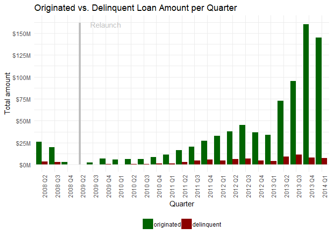

### 2. Loan Issuance By State

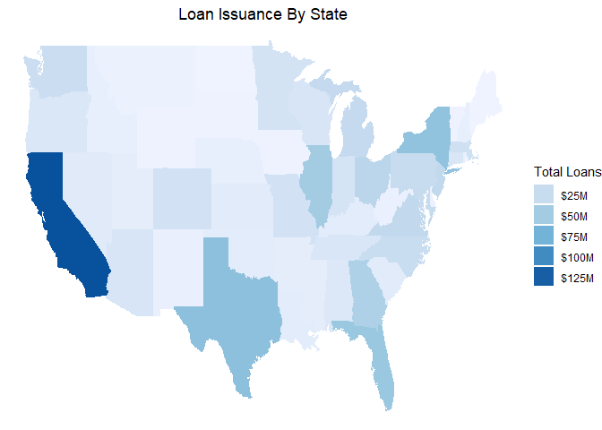

- This plot captures in which states prosper is particulary active. California is their central hub of business region. One reason for this might be that the company is based in this area.

### 3. Borrower rate by ProsperScore and Credit Rating

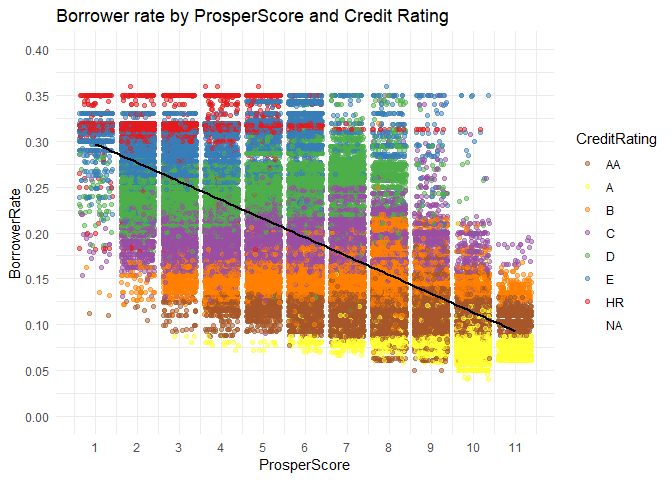

- This graph clearly highlights the relationsship between a persons credit rating, prosper score and the borrower rate they recieved.
- Persons with a better Credit Rating and hence ahigher Prosper Score recieve the better borrowing rates.
- The straight horizontal lines in the graph indicate that there are maximum rates for the different credit ratings set by Prosper.

## Reflection

By exploring and analyzing the dataset of Propser, I have been able to gain insights about the P2P lending business in general and also the business development of Prosper.com. One of the main metrics of interest for loan applicants and lenders is the borrowing rate. I was able to uncover the key factors that influence the interest rate an individual recieves. Furthermore I was able to build a linear model to predict the borrowing rate one recieves, taking into account the credit rate, income, employment status, home-ownership and credit and debt info of an individual.

One of the main challenges was to get familiar with the different variables in the data. With 81 variables per record, exploratory data analysis and plots are particulary important to gain an understanding of the data and to uncover relationships between different variables. R has proven to be a very effective. here.

A promising avenue of future research on the dataset is the analysis of factors which are signs that a loan will not be payed back fully or on time. Building a model which could predict the likelyhood of delinquent loans would greatly reduce the risk taken by the lender and would be a valuable tool for businesses such as Prosper.com.